# SKOC62: Research Methods in Strategic Communication VT25

Quantitative methods workshops 1 — 4

Author

nils.holmberg@iko.lu.se

## 0.1 Introduction

[interactive chart not shown]

- SPSS download student version: [link](https://www.lu.se/studera/livet-som-student/it-tjanster-support-och-driftinfo/programvara)
- SPSS canvas data file: [link](https://github.com/cca-cce/osm-comm/raw/refs/heads/main/csv/cod-220321.sav)
- SPSS tutorial in english: [link](https://www.lse.ac.uk/Methodology/Software-tutorials/SPSS-tutorials)
- SPSS tutorial in swedish: [link](https://www.graduateschool.sam.lu.se/current-students/student-links-and-resources/methods-resources-thesis-writing/how-use-spss)
- Observe that instructions become less and less detailed as you work your way through the tasks.
- Open SPSS. Log into the course website at Canvas. Download the file Communicative Organizations Database.
- **SUPER IMPORTANT!! Save your data file and all changes so you can use it for the following workshops! Also save your output files or copy paste relevant parts to another document if you want to remember what you did in the previous workshop!**

# 1 Workshop: Descriptive statistics

## 1.1 Finding your way around SPSS

1. Open the dataset. Go to variable view in the data window. Take a look at the variable `Gender` (nr 2). What are the possible values of this variable?
2. Inspect the variable `femcomm_mgmt` (nr 32). What does this variable measure? What are the possible values?

## 1.2 First steps: visualizing the data

1. Inspect the variable `Gender` (nr 2) and create a pie chart. Choose: `Analyze -> Descriptive statistics -> Frequencies` in the drop-down menu. Find Gender in the list of variables. You can either double-click it or mark it and click the arrow. Choose: `Charts -> Pie chart -> Continue -> OK`. Observe the results in the Output window. What is the distribution of gender in the sample? Is a pie chart a good way of visualizing this variable? Note: 999 indicates that the respondent did not answer the question; System-missing indicates the question was not asked at all.

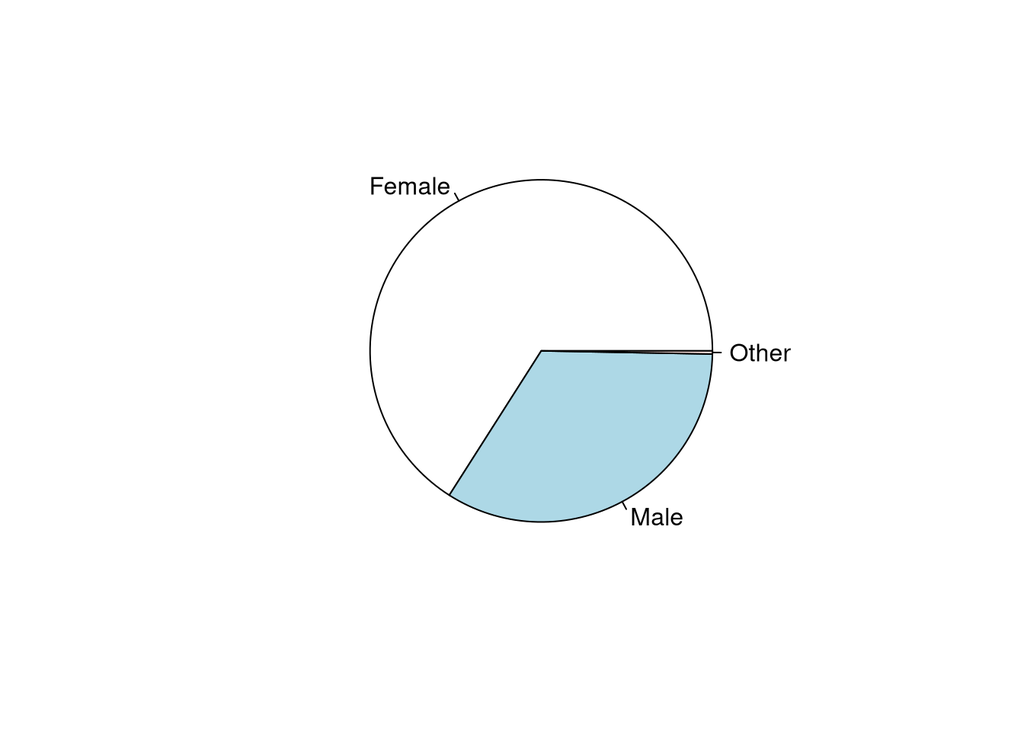

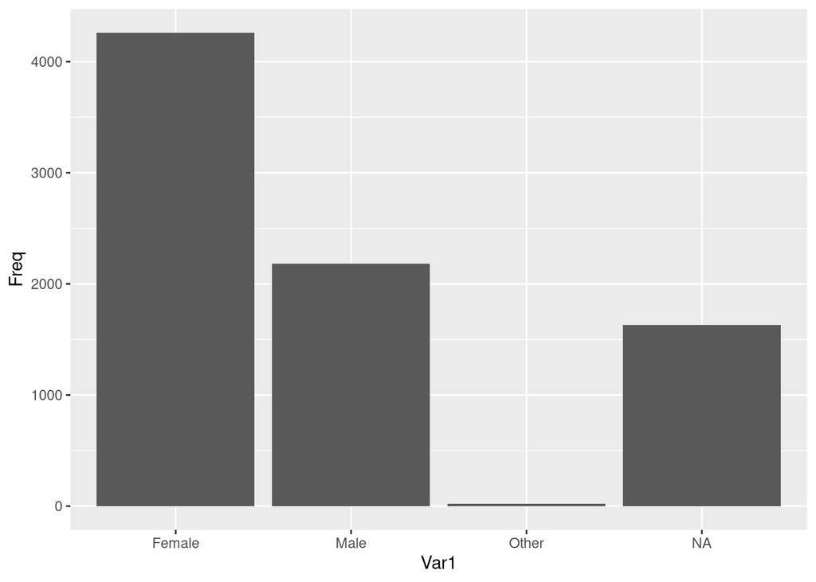

2. Repeat step a using the variable `femcomm_mgmt` (nr 32), but create a bar chart instead of a pie chart. Choose: `Analyze -> Descriptive statistics -> Frequencies -> Charts -> Bar chart`. Observe: by right-clicking the list of variables in the pop-up window, you can choose whether you want the variables displayed by label or name. How did the respondents of the survey answer this question? How many respondents answered this question?
3. Inspect the variable `Role` (nr 5). Create a bar chart. Observer the numbers of communicators in the survey and compare the number to the number of valid responses for femcomm_mgmt (nr 32).

## 1.3 Finding incorrect data

1. Look at the distribution of `Age` (nr 3) and report the mean and the median for the variable. Produce a histogram. Choose: `Frequencies -> Statistics -> Mean and Median -> Continue` and then `Charts -> Histogram -> Continue -> OK`. How is age measured in this variable (= what do the scores represent)? Do some scores seem to be incorrectly reported? What is the highest age? What is the lowest age? What is the median and mean age?
2. Explore the Age variable further by choosing `Analyze -> Descriptive statistics -> Explore` and enter Age into the Dependent variable field. Click on: `Statistics -> Outliers -> Click OK`. Inspect the table Extreme values. Do any of the scores in the table strike you as odd? Go to the box plot (the image shown at the bottom). Note the case numbers shown.
3. Go to data view in the data window. Look up case nr 3611. Choose either of these two options: 1) Change the score to the score you believe is the correct one. 2) Change the score to the median score of the variable.
4. Repeat step c. with other cases where you think the age score might have been entered incorrectly. **Remember to save your changes!**

## 1.4 Cross tables

1. Create a cross table with the variables Gender and femcomm_mgmt. Choose: `Analyze -> Descriptive statistics -> Cross tabs`. Enter the variable Gender into Column(s) and femcomm_mgmt into Row(s). Click: `Cells -> Percentages -> Columns -> Continue -> OK`. Do men and women seem to differ over whether female communicators need to work harder than men in order to secure good relations to management?
2. Repeat 1.4.a with the variables `Role` (nr 5) and `extcomm` (nr 30). Are there any differences in how different groups view the contributions of communicators to effective external communication?

## 1.5 Compare means

1. Do employees of different age perceive gossiping at the workplace differently? Let’s find out! Compare the mean age for different responses to the statement “Gossiping is a problem within the organization” (`org_gossip`, nr. 17). Choose: `Analyze -> Compare means -> Means` from the drop-down menu. Insert Age in the box titled Dependent list and org_gossip in the box titled Independent list. Click OK. (Note: this does not mean that we actually believe that Age is the dependent variable here, since your opinions on gossiping can have no effect on your age. This is only a practical way for us to find out age differences.)

**THAT’S IT FOR TODAY! REMEMBER TO SAVE YOUR DATA AND OUTPUT FILES (THOSE ARE TWO DIFFERENT OPERATIONS)!**

# 2 Workshop: Data transformation

- link

# 3 Workshop: Bivariate analysis

- link

# 4 Workshop: Multivariate analysis

- link
- [osm-comm website](https://cca-cce.github.io/osm-comm/)